# MrBeast Youtube Channels Analytics Report

[figure not shown]

### Author: Precious Iyekeoretin (predeanalyst)

#### INTRODUCTION

- This Report contains information about MrBeast 5 YouTube channels, but more of the analysis on the MrBeast Gaming channel.

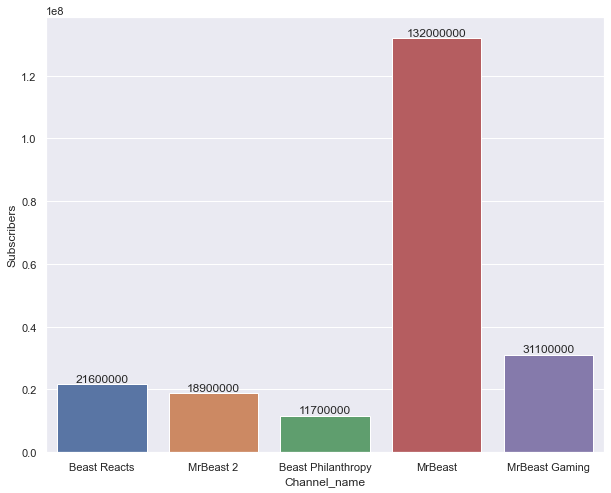

- **FINDINGS:**
- The channel with the most subscribers is MrBeast with 132 million subscribers. The channel with the second most subscribers is MrBeast Gaming with 31.1 million plus subscribers. The channel with the least number of subscribers is Beast Philanthropy with 11.7 million subscribers.

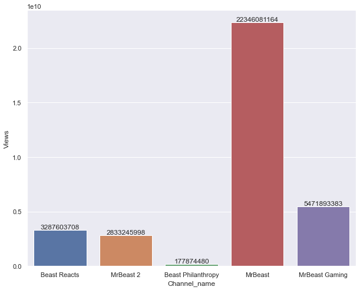

- **FINDINGS:**
- The channel with the most views is MrBeast with 22.3 billion views. The channel with the second most views is MrBeast Gaming with 5.4 billion views. The channel with the least number of views is Beast Philanthropy with 178 million views.

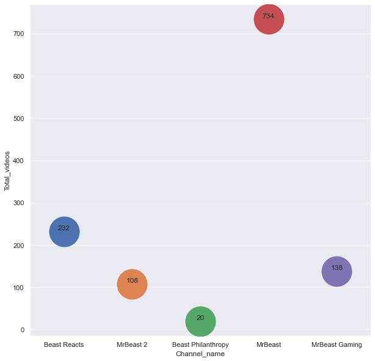

- **FINDINGS:**
- The channel with the most videos is MrBeast with 734 videos. The channel with the second most videos is Beast Reacts with 232 videos. The channel with the least number of videos is Beast Philanthropy with 20 videos.

**In conclusion, the channel with the most subscribers, views, and videos is MrBeast. The channel with the least number of subscribers, views, and videos is Beast Philanthropy.**

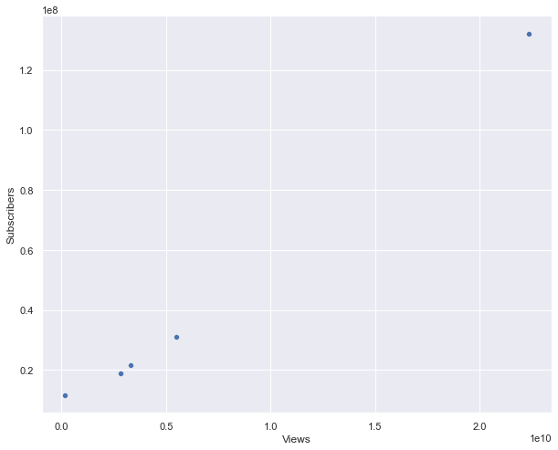

- **FINDINGS:**
- The correlation between subscribers and views is positive, meaning that as the number of subscribers for a channel increases, the number of views for that channel is also likely to increase. One possible explanation for this relationship is that as a channel gains more subscribers, it has a larger audience base to promote its videos to, leading to an increase in views. Additionally, having a large number of subscribers can also serve as a signal of popularity and quality to potential viewers, encouraging them to watch the channel's videos. However, it's also important to keep in mind that other factors, such as the content and quality of the videos, the marketing and promotion efforts of the channel, and the algorithmic recommendations of YouTube, can also play a significant role in determining the number of views a channel receives.

**If you are looking to boost the other 4 channels with low subscribers and views, there are several strategies you can consider:**

1. **Collaboration and cross-promotion:** Consider collaborating with the high subscriber channel (MrBeast) and promoting each other's channels to your respective audiences. This can help bring new viewers to the other channels and boost their subscribers and views.
2. **Content creation and optimization:** Ensure that the other channels are producing high-quality, engaging content that is optimized for discovery and audience retention. This can include using keywords and tags, creating engaging titles and thumbnails, and promoting videos through social media and other channels.
3. **Consistency and frequency:** Regularly upload new content on a consistent schedule to keep viewers engaged and coming back for more. This can help grow the channel's subscribers and views over time.
4. **Engagement and community building:** Encourage engagement with viewers by responding to comments and questions, creating community-driven content, and hosting live streams and other interactive events.
5. **Paid promotions:** Consider using paid promotions, such as YouTube ads or social media advertising, to reach a wider audience and bring new viewers to the channel.
- **NOTE:** It's important to keep in mind that growing a YouTube channel takes time and effort, and there's no one-size-fits-all solution. A combination of these strategies, as well as experimentation and continuous iteration, may be necessary to boost the other channels and reach a wider audience.

# MrBeast Gaming YouTube Channel Analytics

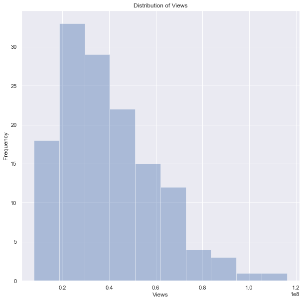

Observation:

- The distribution of views is positively skewed, meaning that most of the videos have fewer views compared to a few videos that have a high number of views. This could indicate that a small number of videos are highly popular and generate a large number of views, while most videos receive relatively fewer views.

Suggestion:

- To boost views, it may be beneficial to focus on creating high-quality content that appeals to a wide audience and can generate viral interest. This could also involve leveraging social media and other marketing channels to reach a wider audience.

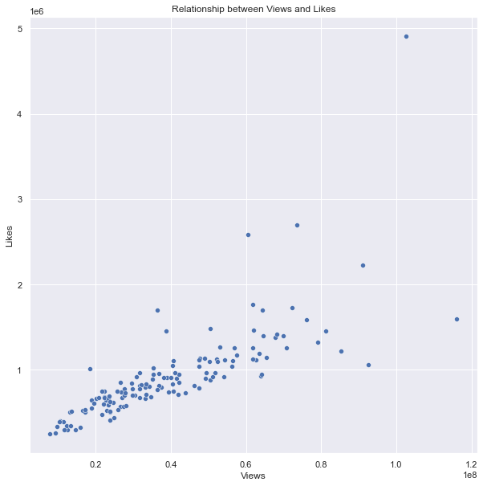

Observation:

- There appears to be a positive relationship between views and likes, meaning that as the number of views increases, the number of likes also tends to increase. This indicates that the popularity of a video is likely tied to both its reach and its appeal to viewers.

Suggestion:

- To increase likes, it may be helpful to create content that is not only widely viewed but also highly engaging and appealing to viewers. This could involve targeting niche interests and communities, as well as creating content that elicits strong emotions or encourages interaction and engagement.

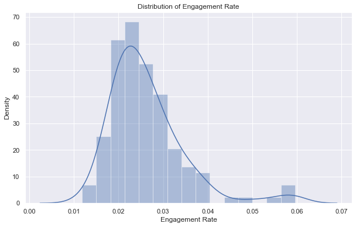

Distribution of Engagement Rate: This plot shows the distribution of the engagement rate, which is calculated as the ratio of (likes + comments) to views. It helps us understand the distribution of the engagement rate across all videos.

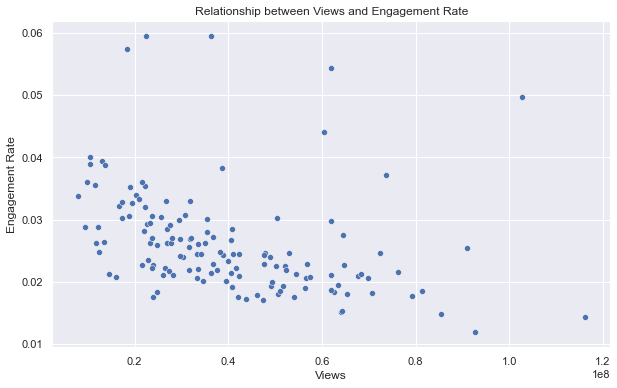

Relationship between Views and Engagement Rate: This scatterplot shows the relationship between views and engagement rate. It helps us understand if there is any correlation between views and engagement rate and how the engagement rate varies with views.

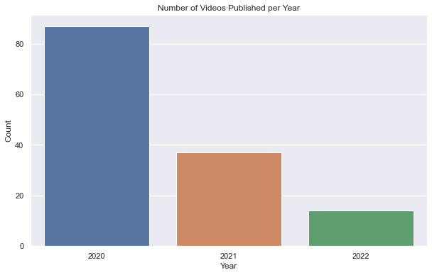

Number of Videos Published per Year: This bar plot shows the number of videos published per year. It helps us understand the trend in the number of videos published over the years.

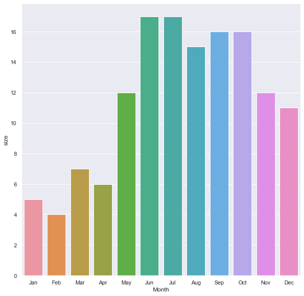

Number of Videos Published per Month: This bar plot shows the number of videos published per month. It helps us understand the trend in the number of videos published across months.

#### TOP 10 VIDEOS BY VIEWS

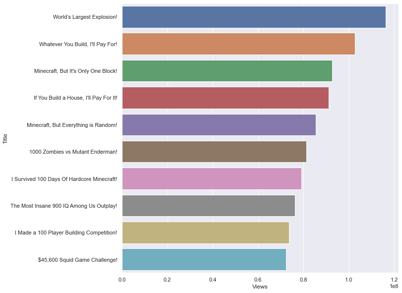

#### BOTTOM 10 VIDEOS BY VIEWS

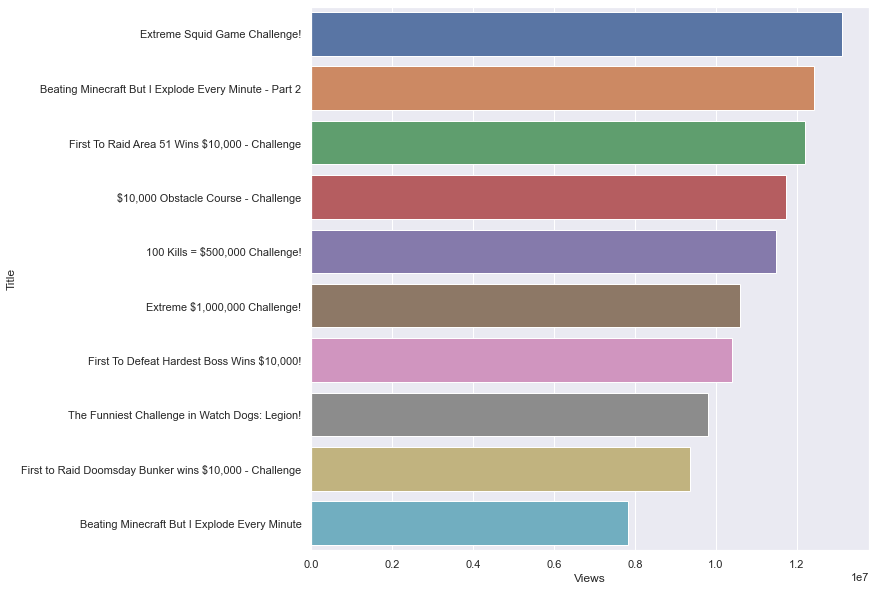